# S11 : Exercices corrigés

### C'est parti pour les linked list les enfants, tout le monde en train on démarre (retenez bien cette idée :) )

[figure not shown]

# QCM

On va utiliser l'implémentation de ces classes de la manière suivante :

```python
class LinkedList:

    def __init__(self):
        self.__length = 0
        self.__head = None

    def add(self, cargo):
        node = Node(cargo,self.__head)
        self.__head = node
        self.__length += 1

    def print(self):
        print("[", end=" ")
        if self.__head is not None:
            self.__head.print_list()
        print("]")

    #...

class Node:

    def __init__(self, cargo=None, next=None):
        self.__cargo = cargo
        self.__next  = next

    def value(self):
        return self.__cargo

    def __str__(self):
        return str(self.value())

    def print_list(self):
        print(self, end="")   # print my head
        tail = self.__next    # go to my next node
        if tail is not None : # as long as end of list was not reached
            tail.print_list() # recursively print remainder of list

    #...s
```

1) On a que la méthode add rajoute un nouveau wagon(node) à l'avant du train(tête de la liste) tout en prenant soin de l'attaché au précédent(next = ancien premier wagon).

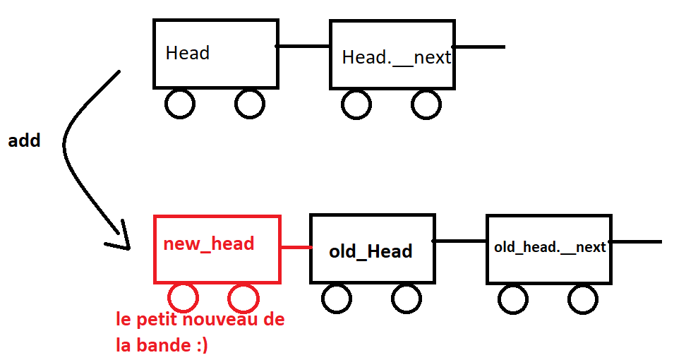

2) Il n'y a pas d'héritage de classe ici, donc pas de raison de parler de classe fille. Node peut également être utilisé ailleurs.  
3) on rajoute maintenant les méthodes accesseurs suivante :

```python
class LinkedList:

    def size(self):
        return self.__length

    def first(self):
        return self.__head

class Node:

    def value(self):
        return self.__cargo

    def next(self):
        return self.__next
```

Quel est l'état de la liste après l'exécution du code suivant :

```python
lst = LinkedList()
lst.add(10)
lst.add(20)
lst.add(30)
```

**Reprenons notre petit train :**

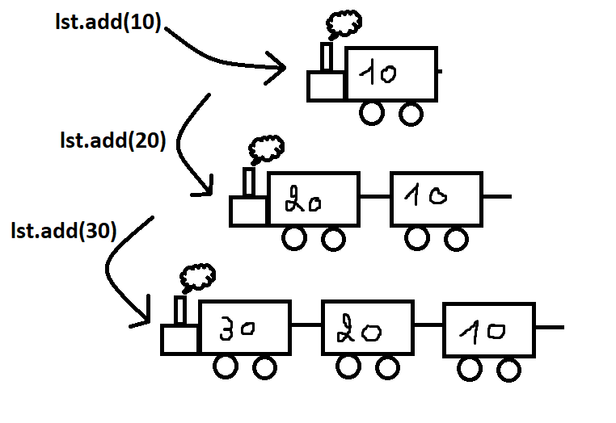

On peut voir que first vaut 30, first.next vaut 20, first.next.next vaut 10 et que first.next.next.next vaut None

4) Comment supprimer l'élément en tête de liste ?

**A quoi faut-il faire super gaffe ?**

> **Conserver** une nouvelle tête pour la liste, sinon elle ne possède plus rien la pauvre  
> **Verifier** qu'il y a bien un **élément dans la liste**  
> Modifier sa **longueur**

**Mais qui est la nouvelle tête ?**

> le **next** du **head** qu'on veut retirer bien évidemment

5) Calculer la somme des noeuds de la liste ? Easy-peasy lemon-squeezie. On démarre de la locomotive (first) on additionne à chaque fois la valeur du wagon(locomotive pour le premier) dans lequel on se trouve avec la somme totale puis on passe au wagon suivant et on répète **MAIS** sautez pas en dehors du train, traduction : faite attention que le next n'est pas None !

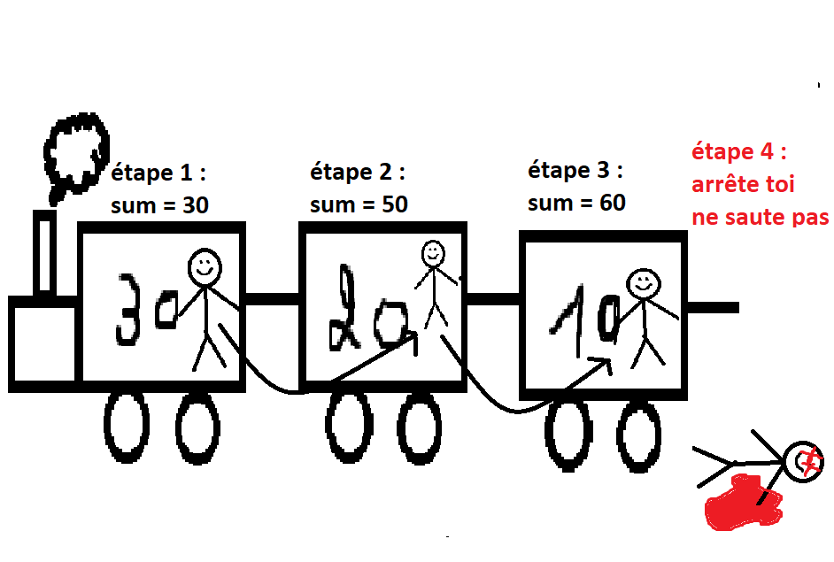

6) Pour swap des wagons il faut d'abord vérifier qu'on en a (eh oui smart hein). Ensuite, il suffit de dire :  
"toi le deuxième tu deviens premier"  
"par contre toi qui était premier maintenant tu te mets derrière le nouveau"

[figure not shown]

# Question 0

### Un peu de théorie et de vocabulaire

### Qu'est ce qu'une liste chainée ?

C'est une **structure de données** qui implémente une collection d'éléments sous la forme d'une **séquence de noeuds connectés**.

### Qu'est ce qu'une structure de donnée ? Donnez un exemple.

C'est un moyen de faciliter l'organisation et le regroupement de donner pour faciliter leur utilisation. Une liste de liens est un exemple typique de structure de données. Elle permet de regrouper des éléments en les organisant dans une structure que l'on peut parcourir de manière séquentielle.

### Expliquez la différence entre un noeud (Node) et sa cargaison (cargo).

Un noeud est un élément d'une liste chainée. Il s'agit d'un **objet** qui **contient une référence** intégrée **à un autre objet du même type** **ET** un élément de données appelé **sa cargaison**. La cargaison est composée des données contenues par un noeud. La référence est ce qui permet de relier les noeuds entre eux !

### Expliquez la différence entre un noeud (Node) et une liste chainée (LinkedList).

Le noeud sert à créer la liste chainée. Donc, une liste chainée est un ensemble de noeuds enchaînés. Il existe plusieurs types de liste chainée : doublement chainées, simplement chainées, cyclique, ...

### Dans le livre et le cours magistral, la notion d'une liste chaînée a d'abord été expliqué sans la classe LinkedList, simplement en chaînant des noeuds l'un à l'autre. Pourquoi avons nous alors besoin d'une classe LinkedList ?

1. la classe LinkedList nous permet de représenter de façon plus cohérente des listes vide.  
   **Question : avec uniquement la classe Node, comment serait représenter une liste vide ?**

[figure not shown]

La liste serait représenter par le type **None**, pas d'entreprise, pas de wagon, pas de chauffeur, pas de gare, pas de locomotive, nada, nothing niks, rien, get it ? Or **avec une classe LinkedList**, elle serait bien du **type LinkedList**, vous auriez la sncb mais sans aucun équipement.

1. la classe LinkedList est la classe qui représente la structure de données qu'est une liste chaînée. La linked list contient la structure et les données de la chaîne, ainsi que l'ensemble de méthodes définies sur cette structure de données.  
   Pour faire le parallèle, la sncb(liste) représente le réseau belge mais ses trains(noeuds) ne le représente pas entièrement. La sncb contient les trains, les marchandises à l'intérieur (pas de trafic humain svp, soyons sérieux), les différents cadres(structure) et travailleurs(méthodes) pour faire marcher la société.

**Remarque :** en pratique vous pourriez cacher l'implémentation de Node dans LinkedList.

### Expliquez et donnez un exemple du caractère ambiguë d'un noeud.

On peut considérer le noeud comme la référence vers le début d'une liste ou bien comme un objet dont on veut accéder aux donneés.

# Question 1

Le mieux, c'est de le faire soit-même avec votre environnement préféré (Thonny, pyCharm, ...), prédire le résultat et vérifier/comprendre si erreur.

[figure not shown]

# Question 2

### Imprimer une liste chaînée

Dans le code donné dans l'annexe [**Appendix - Source code of linked lists**](https://syllabus-interactif.info.ucl.ac.be/syllabus/info1-theory/PART_III/appendix_code_linked_list) la méthode print() de la classe LinkedList imprime les éléments d'une liste chaînée, séparés par une espace. Par exemple:

```python
>>> l = LinkedList()
>>> l.add(3)
>>> l.add(2)
>>> l.add(1)

>>> l.print()
[ 1 2 3 ]
```

#### Or, normalement la convention est de séparer les éléments d'une liste par des virgules. Ajoutez une nouvelle méthode print_avec_virgule() dans la classe LinkedList qui imprime la liste comme suite:

```python
>>> l.print_avec_virgule()
[ 1, 2, 3 ]
```

**Attention:** il n'y a pas de virgule après le dernier élément ou si on imprime une liste vide.

```python
>>> l = LinkedList()
>>> l.print_avec_virgule()
[ ]
```

### Alors combien de méthode va-t-on devoir définir ?

[figure not shown]

#### En effet, il va en falloir une dans node, et une dans la liste !

**https://www.overleaf.com/6523357593fnwnvkwvsbyr**

# Question 3

### Imprimer une liste chainée

Généralisez la méthode print_avec_virgule de l'exercice précédente par une méthode print_avec_separateur qui peut prendre n'importe quelle séparateur. Par exemple:

```python
>>> l = LinkedList()
>>> l.add(3)
>>> l.add(2)
>>> l.add(1)

>>> l.print_avec_separateur(", ")
[ 1, 2, 3 ]
>>> l.print_avec_separateur(" ")
[ 1 2 3 ]
>>> l.print_avec_separateur(" - ")
[ 1 - 2 - 3 ]
```

#### Est-ce qu'on doit tout redéfinir où ça peut aller vite ?

#### Réponse :

[figure not shown]

là où on mettait un print(head, end=", "), on peut simplement attribuer à end l'argument de la fonction

# Question 4

### Initialiser une liste chainée

Changez la méthode d'initialisation __init__ de la classe LinkedList (cf. l'annexe [**Appendix - Source code of linked lists**](https://syllabus-interactif.info.ucl.ac.be/syllabus/info1-theory/PART_III/appendix_code_linked_list) ), afin qu'elle prenne une liste Python comme paramètre pour initialiser la liste chaînée. Spécifier bien cette nouvelle méthode __init__ avec des conditions pre et post.

```python
def __init__(self, lst=[]):
    self.__length = 0
    self.__head = None
    # initialiser la liste chainêé avec les éléments de lst ...
```

#### Exemple :

```python
>>> l = LinkedList([1,2,3])
>>> l.print()
[ 1 2 3 ]

>>> l = LinkedList([])
>>> l.print()
[ ]
```

### Il y a une subtilité au problème dans son implémentation que j'ai retiré de l'énoncé, quelle est-elle ?

[figure not shown]

Le premier élément de cette liste doit devenir le premier élément de la liste chainée, et ainsi de suite !  
Petite illustration :

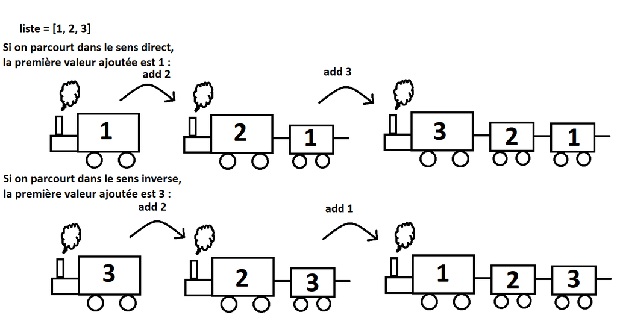

### Mettez vos petites implémentations sur l'overleaf :)

# Question 5

### Supprimer un élément

Ajoutez à la classe LinkedList (cf. l'annexe [**Appendix - Source code of linked lists**](https://syllabus-interactif.info.ucl.ac.be/syllabus/info1-theory/PART_III/appendix_code_linked_list) ) une méthode remove() pour supprimer le noeud en tête de la liste. Si la liste chaînée était déjà vide, cette méthode ne fait rien.

```python
l = LinkedList()
l.add(3)
l.add(2)
l.add(1)
l.print()
# [ 1 2 3 ]
l.remove()
l.print()
# [ 2 3 ]
l.remove()
print(l.length)
# 1
l.remove()
l.print()
# [ ]
l.remove()
l.print()
# [ ]
```

### Attenzione signore e signori, qu'est-ce qu'on doit pas oublier ?

- décrémenter la longueur de la liste
- attribuer la nouvelle valeur de la tête
- on doit utiliser la méthode accesseur puisque next est privé !
- on ne viole pas les lois de la nature en supprimant quelque chose qui n'existe pas (i.e None)

# Question 6

# WATER CHECKPOINT

[figure not shown]

### Tout le monde boit un petit coup d'eau pour se rafraichir les neurones, ça fume.

### Ajouter un élément à la fin

Ajoutez à la classe LinkedList une méthode add_to_end(self, cargo) pour ajouter un noeud en queue de la liste. Ajoutez d'abord un nouvel attribut last dans la méthode d'initialisation pour garder une référence vers ce dernier élément. Changez ensuite la méthode add pour assigner cette référence lors de l'ajout du premier noeud, et la méthode remove pour remettre cette référence à None lorsque la liste est de nouveau vide. Implémentez ensuite la méthode add_to_end.

### Alors reprenons dans l'ordre de manière structurée

- self.last dans le __init__
- self.add_to_end(dernier_element_de_la_liste) dans le constructeur
- Si on ajoute un élément pour la première fois à l'aide de add, initialiser last à ce noeud
- Si on retire le seul élément présent dans une liste, initialiser last à None
- La petite subtilité : il nous faut une méthode set_next pour la classe Node.

# Question 7

### Supprimer un élément à la fin

Est-ce facile d'implémenter une méthode remove_from_end(self, cargo) pour supprimer un élément de la queue d'une LinkedList? Expliquez en mots comment vous feriez

### let's hear your idea

[figure not shown]

- Suffit pas un pointeur vers le dernier, si on veut éviter de devoir parcourir la liste entière chaque fois pour retrouver le dernier élément, il faut connaître aussi l'avant-dernier élément, qui deviendra le dernier.
- Mais cela ne résout pas le problème. Car si on supprime le dernier, comment alors retrouver l'avant-avant-dernier qui deviendra l'avant-dernier?  
  Le mieux est de pouvoir parcourir les listes en avant et en arrière, donc une liste doublement chainée !

# Question 8

### Imbriquer une classe dans une autre

En Python il est possible d'imbriquer une classe dans une autre. Ceci peut être utile si une classe n'est utilise que par une seule autre classe. C'est le cas ici avec la classe Node. Ce n'est qu'une classe auxiliaire pour la classe LinkedList. Adapter le code de votre classe LinkedList en imbriquant le code de la classe Node dedans. Il suffit d'indenter le code de la classe Node et de changer chaque référence à la classe Node à l'interieur de la classe LinkedList par self.Node.

- Il suffit d'indenter la classe Node dans la LinkedList et remplacer des appels par self.Node.

#### Quels sont les avantages et désavantages d'imbriquer la classe Node dans la classe LinkedList?

- **Avantage :** la classe est cachée de l'extérieur de la classe LinkedList.
- **Désavantage :** la classe Node devient plus difficile à tester indépendamment, code de la LinkedList devient long et la classe Node n'est plus utilisable pour créer d'autre structure.

# Question 9

### Insérer un élément

Considérez qu'on désire utiliser la classe LinkedList pour stocker une liste de strings. On souhaite qu'elle soit en permanence en ordre alphabétique croissant.

### Dessinez complètement une telle liste chainée contenant les trois strings "abc", "def" et "xyz".

### Expliquez en français et dessinez les opérations à effectuer pour ajouter un Node contenant "aaa" dans cette liste

### Même question avec un Node contenant "ghi".

### Même question avec un Node contenant "def"

### Même question avec un Node contenant "zzz".

### Let's go sur paint :)

# Question 10

Comment feriez-vous pour écrire dans la classe LinkedList (cf. l'annexe [**Appendix - Source code of linked lists**](https://syllabus-interactif.info.ucl.ac.be/syllabus/info1-theory/PART_III/appendix_code_linked_list) ) la méthode insert dont la spécification est la suivante:

```python
def insert(self,s):
    """
    @pre  s est un string à insérer dans la liste chainée;
          self est une liste chaînée dont les noeuds contiennent des strings;
          les noeuds de la liste sont ordonnées en ordre croissant selon les valeurs (strings)
          qu'ils contiennent.
    @post Un noeud contenant le String s a été inséré dans la liste de façon
          à ce qu'après l'insertion celle-ci soit toujours en ordre croissant.
    """
```

Pour rappel, en Python on peut facilement comparer un string avec un autre avec l'opérateur <. Vous pouvez aussi considérez que la classe Node se trouve maintenant à l'intérieur de la classe LinkedList et possède la méthode mutateur suivante:

```python
class LinkedList:
    #...

    class Node:

        def set_next(self,node):
            self.__next = node
```

### Comment décomposer le code ? Quels sont les différents cas ?

[figure not shown]

- la liste est vide, on ajoute le premier élément
- le nouvel élément à ajouter est avant la tête de liste
- le nouvel élément à ajouter se situe à une place non-trivial
- le nouvel élément à ajouter se situe à la fin

### Plus qu'à implémenter une fonction répondant à ces différents cas.

[figure not shown]

# Merci pour votre écoute à la RADIO LINFO1101, la radio qui ramène des pythons dans vos campagnes !